# SignatureAnalyzer pipeline

WU Fengyuan[^1]

2021/11/8

## Overview

Somatic mutations are present in all cells of the human body and occur throughout life. They are the consequence of multiple mutational processes, including the intrinsic slight infidelity of the DNA replication machinery, exogenous or endogenous mutagen exposures, enzymatic modification of DNA and defective DNA repair. Different mutational processes generate unique combinations of mutation types, termed “Mutational Signatures”.  
SignatureAnalyzer is a tool which exploits a Bayesian variant of Non-negative matrix factorization(NMF) algorithm to detect mutational signatures and enables an inference for the optimal number of signatures from data itself at a balance between the “data fidelity” (likelihood) and the “model complexity” (regularization).

## Pipeline

**1.Installation**

Up to now (2020/10/5) the newest version (0.8) hasn’t been uploaded to pip. You can download SignatureAnalyzer 0.8 from github, then directly head to installation step.

**2.Input files**

[output not shown]

**3.Run SignatureAnalyzer**

```r
signatureanalyzer -n 8 \ ## Number of threads
--hg_build hg38.2bit \ ## Reference genome
--objective poisson \ ## For mutational signatures, SignatureAnaltzer assumes a poisson distribution of counts and use Fevotte & Tan's derivation of a poisson objective function for ARD-NMF. Thus, it is important to use the default value for the objective function (poisson).
--reference pcawg_COMPOSITE \ ## Turn to Q&A
--prior_on_H L1 \ ## Impose an exponential (L1) prior on the W & H matrices for non-negative matrix factorization.
--prior_on_W L1 \
test.maf ## input maf file
```

**4.Plotting**

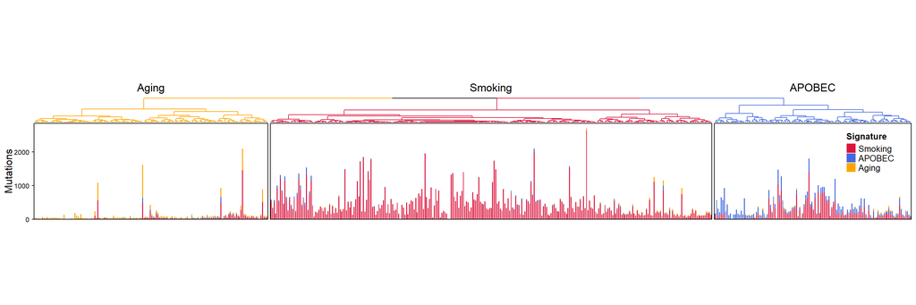

```r
options(warn = -1)
suppressMessages(library(rhdf5))
suppressMessages(library(ComplexHeatmap))
suppressMessages(library(dendextend))
##read and process NMF output
test=h5ls("nmf_output.h5")
abs_data=h5read("nmf_output.h5", "/H")
abs_mat=abs_data$block0_values
colnames(abs_mat)=abs_data$axis1
abs_mat=abs_mat[1:3,]
rownames(abs_mat)=c("Smoking","APOBEC","Aging")
rel_data=h5read("nmf_output.h5","/Hraw")
rel_mat=rel_data$block0_values
rownames(rel_mat)=rel_data$block0_items
colnames(rel_mat)=rel_data$axis1
rel_mat=scale(rel_mat,center=F,scale=colSums(rel_mat))
##hierarchical clustering
hc=hclust(dist(t(rel_mat)))
hc = color_branches(hc, k = 3,col=c("#FFA500","#DC143C","#4169E1"))
##draw with complexheatmap
lgd=Legend(labels = rownames(abs_mat), title = "Signature",legend_gp = gpar(fill = c("#DC143C","#4169E1","#FFA500")))
annot=HeatmapAnnotation(Mutations=anno_barplot(t(abs_mat),
                                               border=TRUE,
                                               height = unit(4,"cm"),
                                               gp=gpar(lty="blank",fill=c("#DC143C","#4169E1","#FFA500"))),
                        annotation_name_side="left",
                        annotation_name_rot=90,
                        show_legend = TRUE)
Heatmap(matrix(nc=dim(rel_mat)[2],nr=0),cluster_columns =hc,
        top_annotation = annot,
        column_split = 3,
        column_title = c("Aging","Smoking","APOBEC")
        )
draw(lgd,x = unit(0.95, "npc"), y = unit(0.5, "npc"))
```

**5.Supervised NMF**

SigantureAnalyzer can perform supervised NMF, but the code is not as integrated as unsupervised version. Here is an example in python.  
If you got few patients(<100) even with multiple samples per patients, the results of unsupervised NMF is untrustworthy for the high possibility of overfitting. In this occasion, you should use signatures found in large cohorts to perform supervised NMF.

```r
import pandas as pd
import signatureanalyzer as sa
import matplotlib.pyplot as plt
import numpy as np

# maf path, reference path and the signatures to perform supervised NMF
MAF_PATH = "test.maf"
HG_PATH = "hg19.2bit"
REF="cosmic3_exome"
SIG_LIST = ["SBS1","SBS4","SBS5","SBS6","SBS12","SBS16","SBS17a","SBS17b","SBS22","SBS24","SBS23"]
MAX_ITER = 30000

# Read maf file and extract mutation spectra
maf = pd.read_csv(MAF_PATH,sep='\t')
maf,spectra_df = sa.spectra.get_spectra_from_maf(maf, hgfile=HG_PATH, reference=REF)

# Import signature reference data
ref_df,ref_index= sa.utils.load_reference_signatures(REF)

# Map spectra index to ref index
spectra_df.index = sa.utils._map_sbs_id_sigs(spectra_df,ref_df,REF)

# Subset reference data to create W matrix
Wref_df = ref_df.set_index('Somatic Mutation Type').iloc[:,:-2]
Wref_df = Wref_df.loc[:, SIG_LIST]

# Run supervised NMF
res_supervised = sa.supervised_bnmf.supervised_ardnmf(
    spectra_df,
    Wref_df,
    objective='poisson',
    verbose=True,
    max_iter=MAX_ITER)

# Store results in an h5 file
store = pd.HDFStore('nmf_output.h5','a')
store["H"] = res_supervised["H"]
store["W"] = res_supervised["W"]
store["Hraw"] = res_supervised["Hraw"]
store["Wraw"] = res_supervised["Wraw"]
store["markers"] = res_supervised["markers"]
store["signatures"] = res_supervised["signatures"]
store["log"] = res_supervised["log"]
store.close()

# Optional: Generate signature weighted maf file
H = res_supervised["H"]
W = res_supervised["W"]
vir=maf[W.index.name.split(".")+".num"]
vir.index=maf[W.index.name]
maf[W.index.name]=sa.utils._map_sbs_id_sigs(vir,ref_df,REF)
weighted_maf = sa.utils.assign_signature_weights_to_maf(maf, W, H)
weighted_maf.to_csv('signature_weighted_maf.tsv', sep='\t', index=False)

# Plotting
_ = sa.plotting.signature_barplot(W, contributions=np.sum(H))
plt.savefig("signature_contributions.pdf", dpi=100, bbox_inches='tight')
_ = sa.plotting.stacked_bar(H,REF)
plt.savefig("signature_stacked_barplot.pdf", dpi=100, bbox_inches='tight')
```

## Results and Q&A

**1.Cosmic and PCAWG signature options**

| Options | Description |
| --- | --- |
| cosmic3 | 96-base SBS signatures for WGS |
| cosmic3_exome | 96-base SBS signatures for WES |
| cosmic3_DBS | DBS sigantures |
| cosmic3_ID | ID signatures |
| cosmic3_TSB | SBS signatures with transcriptional strand bias information |
| pcawg_COMPOSITE | composite signatures(coexatraction of 1536 SBS+DBS+ID) |
| pcawg_COMPOSITE96 | composite signatures(coexatraction of 96 SBS+DBS+ID) |
| pcawg_SBS_ID | coexatraction of 1536 SBS+ID |
| pacwg_SBS96_ID | coexatraction of 96 SBS+ID |
| polymerase_msi | 1536 SBS+ID, exonuclease domain of DNA polymerase epsilon (POLE-exo*) related |
| polymerase_msi96 | 96 SBS+ID |

PCAWG recommend to use composite attributions to extract SBS signatures but extract DBS and ID signatures separately.  
Note that signatureanalyzer does support use pacawg signatures when the reference genome is hg19.

**2.Output files**

| Files | Description |
| --- | --- |
| nmf_output.h5 | H matrix, W matrix, cosine similarity and all other information. |
| cosine_similarity_plot.pdf | Cosine similarity between de nove extracted signatures and known signatures. |
| signature_contributions.pdf | Mutation contents of signatures. |
| signature_stacked_barplot | Contribution of different processes to mutations of samples. |

**3.H and W matrix**

NMF can decompose the mutation count matrix into H and W matrix.  
The H matrix describes the number/percent of mutations of a sample can be attributed to each signatures.  
The W matrix contains the combination of mutations of signatures extracted by NMF.

[^1]: Institute of Zoology, CAS wufengyuan@ioz.ac.cn